# Worked Example: D-Rex

Johan Larsson

## Probing an Unknown Dataset

Let’s say that we have data from an unknown source, containing two variables, `x` and `y`. The data has been uploaded to the course website, and you can download and read it into your workspace with the following command.

```r
library(tidyverse)

xy <- read_csv(
  "https://raw.githubusercontent.com/stat-lu/dataviz/main/data/xy.csv"
)
```

### Box Plot

Let’s try to explore the univariate distributions of these two variables. We begin with a box plot.

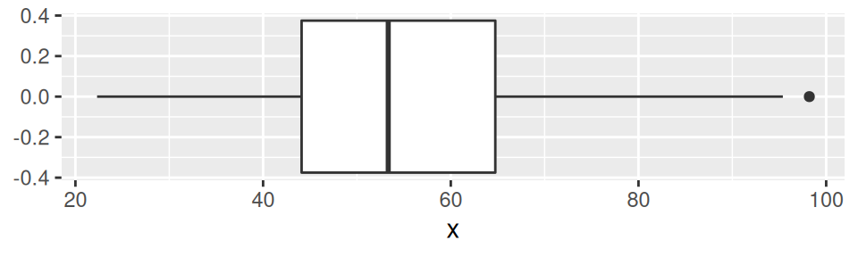

A boxplot of the x variable.

```r
ggplot(xy, aes(x)) +
  geom_boxplot()
```

As you see, our call to ggplot2 is quite simple. We use `ggplot()` with the data as the first argument and a call to `aes()` for our aesthetics specification as our second argument. The call to `aes()` is actually optional and if you want to you can provide your mappings inside the layers (geom functions) if you want to.

The distribution seems to be reasonably symmetric but with a longer tail to the right and with a single outlier at around 100. The boxplot also indicates that the distribution is uni-modal, with a center around 55. But this is the problem with boxplots: they can never “discover” anything *but* a single mode, since boxplots are based on statistics only related to the quantiles of the distribution.

### Dot Plot

When studying a distribution, it is usually better to start off with a plot that does less abstraction, such as a simple dot plot. In a dot plot, each observation is indicated by a dot.

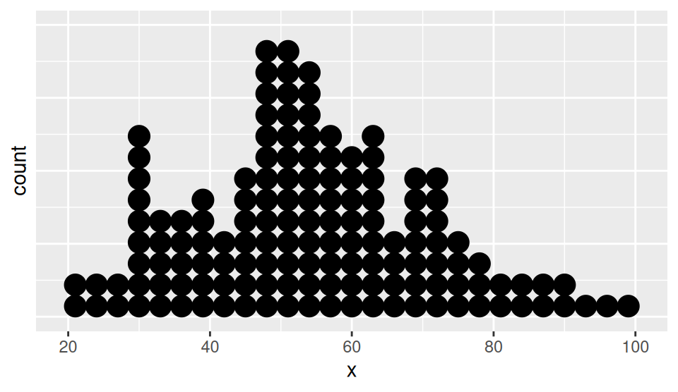

A dotplot of the x variable.

```r
ggplot(xy, aes(x)) +
  geom_dotplot(method = "histodot", binwidth = 3) +
  guides(y = "none") # do you remember why we did this?
```

Try changing the `method` argument to the default, and then try playing a bit with the `binwidth` settings.

It’s hard to summarize this distribution in a few words, but it does not quite seem to be uni-modal. There is also a slight indication that the values may be biased towards certain values here, which for instance is a common problem in questionnaires, where many will “round off” their answers to a whole number when they are uncertain about the answer.

### Histogram

Perhaps this is the case here, so let’s use a *histogram* instead. Just as with the dot plot, we need to specify the bin width (or number of bins) here. Given the number of observations here, and the dot plot we previously plotted, a bin width of five might be appropriate to remove the effect of possible round-off bias and elucidate the shape of the distribution better.

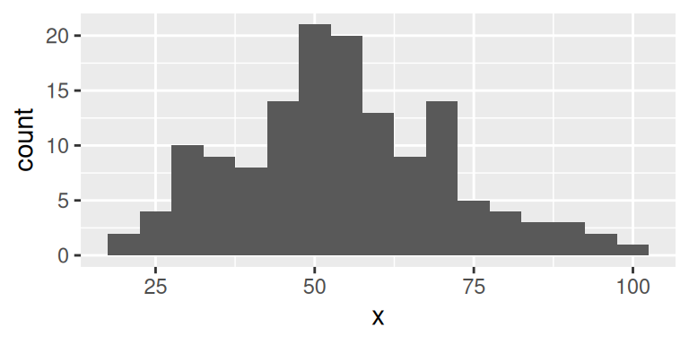

A histogram of the x variable.

```r
ggplot(xy, aes(x)) +
  geom_histogram(binwidth = 5)
```

Play around a little bit with the various settings of `bins` and/or `binwidth` to see how large the effects of these parameters can be.

### Density Plot

We could also try a density plot here. Density plots are best when you know that your data is measured on a continuous scale and can make strong assumptions about the distributions of your variables, since the choice of parameters for the density kernel have large effects on the result.

Here we try a few different choices to highlight this.

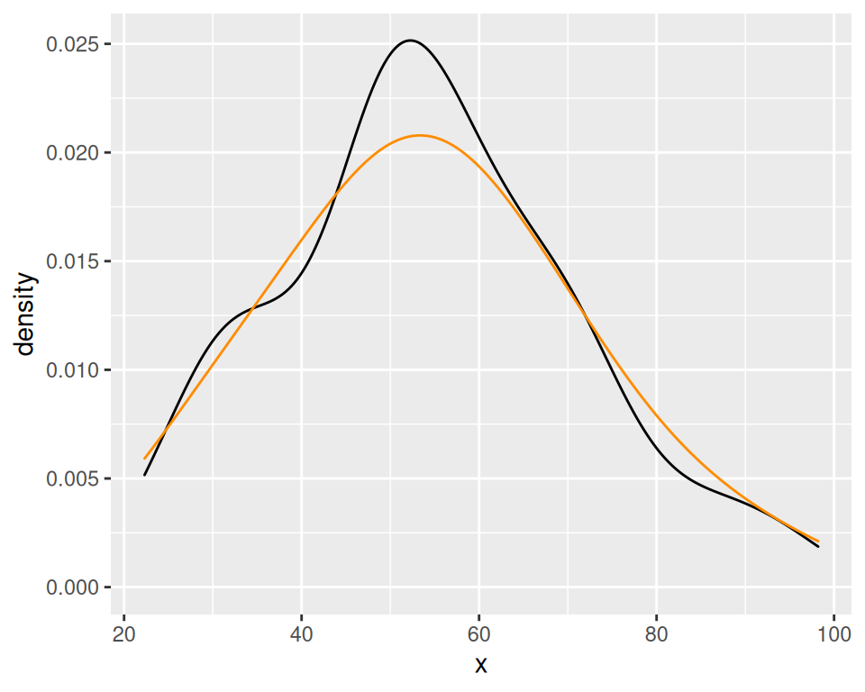

Density plots with various density estimate choices.

```r
ggplot(xy, aes(x)) +
  geom_density() + # kernel = "gaussian", the default
  geom_density(col = "dark orange", bw = 10)
```

Try adding another density estimate, this time with a *rectangular* kernel.

The default density layer uses Silverman’s rule-of-thumb (see `?bw.nrd0`) for choosing band width but there are other choices that are probably better, such as `bw = "SJ"`. Try this out too.

### Compactly Displaying Several Univariate Distributions

It can sometimes be useful to display several plots of univariate distributions in a compact design. One way to do so is via the patchwork package, which can be used to *patch* together plots that you have created separately. Let’s install the package first.

```r
install.packages("patchwork")
```

**patchwork** is simple and inituitive yet powerful. Most of its functionality can be obtained simply by using unary operators (such as `+`) to patch plots together. `+` and `|` are used to patch plots horizontally, and `/` to patch them vertically.

In the following plot, we patch a histogram and density plot together.

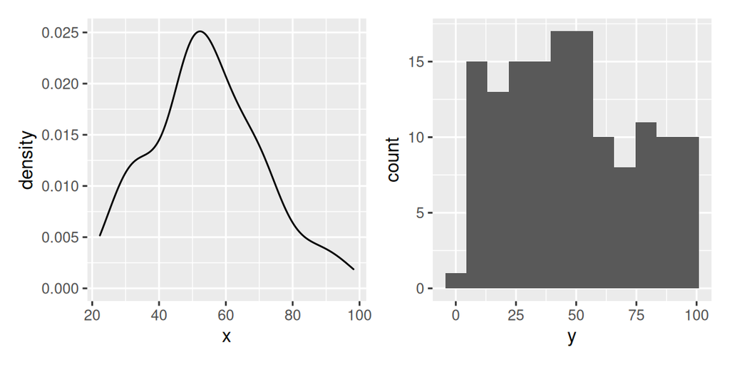

Density plot of x and histogram of y.

```r
library(patchwork)

p1 <- ggplot(xy, aes(x)) +
  geom_density(bw = "SJ")

p2 <- ggplot(xy, aes(y)) +
  geom_histogram(bins = 12)

p1 | p2
```

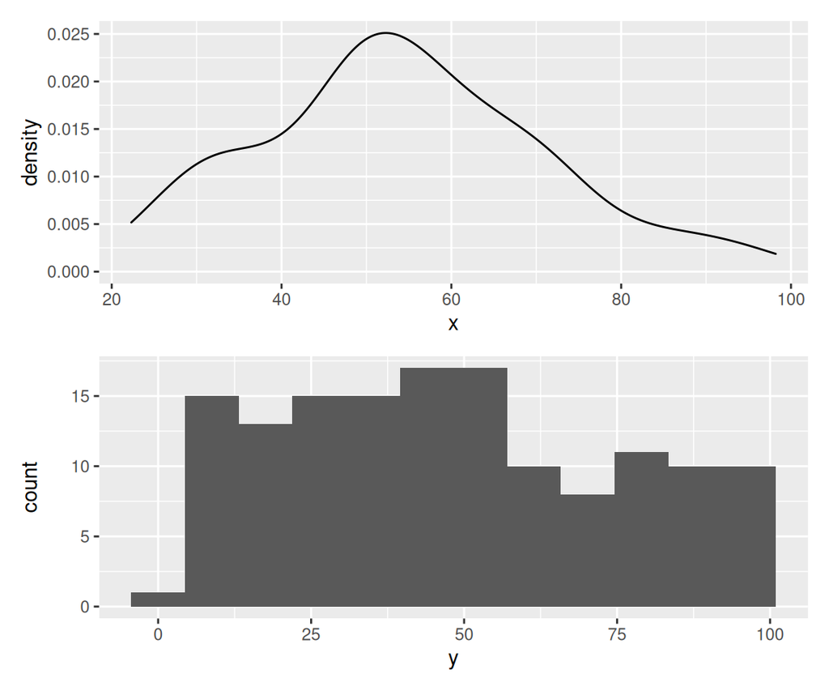

Density plot of x and histogram of y.

```r
p1 / p2
```

And here is an example where we go one step further, using a more complicated layout and addings labels to the plots.

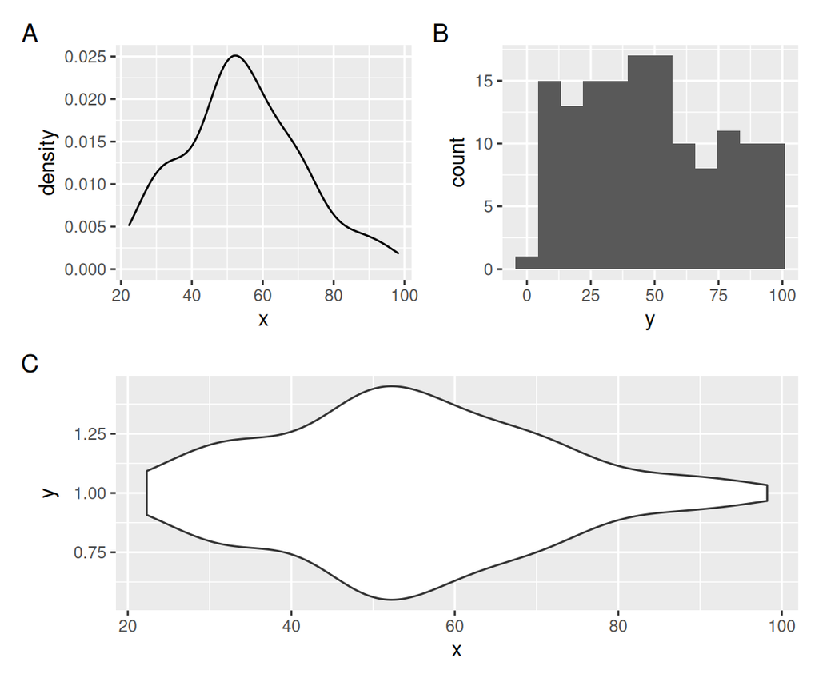

```r
p3 <- ggplot(xy, aes(x, y = 1)) +
  geom_violin()

pw <- (p1 | p2) / p3

pw + plot_annotation(tag_levels = "A")
```

Simple, right? Play around with patchwork and it’s various options. One thing that can be particularly useful to know about is that if you have a legend, such as a color legend, that’s shared between the plots you’re patching together, then patchwork will automatically merge these guides into one.

For more examples, check out [documentation](https://patchwork.data-imaginist.com/index.html).

## Rawr!

We’ve now plotted several types of plots of the distributions of this dataset and might well feel comfortable about making a few conclusions about the data. Stopping here, however, would unfortunately be a severe mistake. Because what we’ve missed is to plot the *joint* distribution of these variables, which is very easy to do using a scatter plot (which we will tackle in much more detail during the next part of the course).

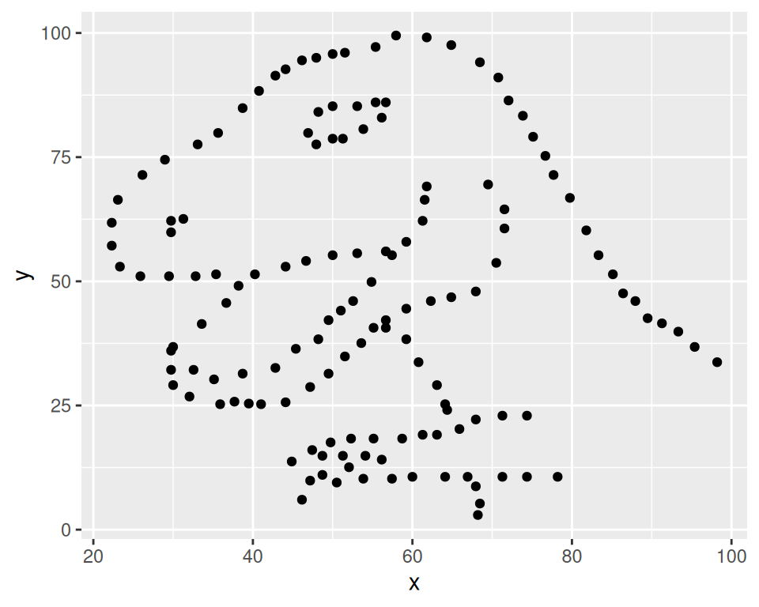

The terrifying Datasaurus Rex.

```r
ggplot(xy, aes(x, y)) +
  geom_point()
```

What is the take-home message here? Well, it’s twofold:

1. When you visualize distributions of several variables one by one, you are projecting these distributions from a multivariate space to a univariate space. In so doing, you are effectively ignoring all of the ways by which these two variables are related to one another. To be fair, it isn’t always easy (or even possible) to visualize many variables at once, but in this case we would have been far better off if we had considered a scatter plot right away.
2. Knowing your data is critical. You should never throw yourself into a dataset without at least a bit of understanding about what the variables represent and preferably also how they were collected. Make it a habit to read up on the dataset *before* you start visualizing it. For most of the data that we’ll tackle in this course, there is often documentation that you can access by looking at the help file for the dataset.

## Source Code

The source code for this document is available at https://github.com/stat-lu/dataviz/blob/main/worked-example-drex.Rmd.

[^1]: Remember him? The author of the original grammar of graphics.